# eQTL B6 vs BXD references

Nastassia Gobet

2020-11-24

# Goal

See which gene eQTLs are the most different between B6 and BXD references.

# Information

Doing this in default STAR setting (genotypesandimputed_withannotation_Local_0_10) because also available with B6 mm10 reference (abbreviated B6)

FastQTL output (http://fastqtl.sourceforge.net/):

- rowname = ID molecular phenotype (gene)
- V2 = number of variant tested
- V3 = MLE of shape 1 parameter of beta distribution
- V4 = MLE of shape 2 parameters of beta distribution
- V5 = to be described (not explained on FastQTL website)
- V6 = ID of best variant
- V7 = distance between variant and molecular phenotype
- V8 = p-value of association between variant and molecular phenotype
- V9 = slope of regression
- V10 = first permutation p-value accounting for multiple variants tested by molecular phenotype
- V11 = second permutation p-value obtained with beta approximation (recommended to use this one)

# Analysis

## Functions definitions

```r
prepareRawCounts <- function(counts, ref){

  # convert gene ids to gene names
  idx_uniq <- which(!duplicated(GeneConvert$V2[match(rownames(counts), GeneConvert$V1)]))
  counts <- counts[idx_uniq,]
  rownames(counts) <- GeneConvert$V2[match(rownames(counts), GeneConvert$V1)]

  # change X into C for cortex
  colnames(counts) <- gsub("X", "C", colnames(counts))
  # split by tissue and condition
  CortexNSD <- subset(counts, select=grep("^C[0-9]*nsd$", colnames(counts), value=TRUE))
  CortexSD <- subset(counts, select=grep("^C[0-9]*sd$", colnames(counts), value=TRUE))
  LiverNSD <- subset(counts, select=grep("^L[0-9]*nsd$", colnames(counts), value=TRUE))
  LiverSD <- subset(counts, select=grep("^L[0-9]*sd$", colnames(counts), value=TRUE))
  # clean and formate names of mouse lines
  colnames(CortexNSD) <- LinesNames$V5[match(gsub("[LCnsd]", "", colnames(CortexNSD)), LinesNames$V10)]
  colnames(CortexSD) <- LinesNames$V5[match(gsub("[LCnsd]", "", colnames(CortexSD)), LinesNames$V10)]
  colnames(LiverNSD) <- LinesNames$V5[match(gsub("[LCnsd]", "", colnames(LiverNSD)), LinesNames$V10)]
  colnames(LiverSD) <- LinesNames$V5[match(gsub("[LCnsd]", "", colnames(LiverSD)), LinesNames$V10)]

  # output 4 datasets
  assign(paste0("counts", ref, "ref_CortexNSD"), CortexNSD, envir=parent.frame())
  assign(paste0("counts", ref, "ref_CortexSD"), CortexSD, envir=parent.frame())
  assign(paste0("counts", ref, "ref_LiverNSD"), LiverNSD, envir=parent.frame())
  assign(paste0("counts", ref, "ref_LiverSD"), LiverSD, envir=parent.frame())
}

# find top 3 genes for affected
top3genes <- function(tissue, condition){
  t <- unlist(strsplit(tissue, split=""))[1]

  dataB6 <- eval(parse(text=(paste0("dataB6", t, condition))))
  dataB6full <- eval(parse(text=(paste0("dataB6full", t, condition))))
  dataBXD <- eval(parse(text=(paste0("dataBXD", t, condition))))
  dataBXDfull <- eval(parse(text=(paste0("dataBXDfull", t, condition))))

  # identify genes in common between the B6 and BXD lists
  commoneGenes <- intersect(rownames(dataB6), rownames(dataBXD))

  # remove genes with 0 variants
  commoneGenes <- setdiff(commoneGenes, rownames(dataB6full)[dataB6full$V2==0])

  # bigger difference in slope
  orderedgenes <- commoneGenes[order(abs(dataB6full[commoneGenes, "V9"]-dataBXDfull[commoneGenes, "V9"]), decreasing=TRUE)]
  ##dataB6full[match(orderedgenes[1:3], rownames(dataB6full)),]
  ##dataBXDfull[match(orderedgenes[1:3], rownames(dataBXDfull)),]
  outtable <- cbind(dataB6full[orderedgenes[1:3], c(5, 8)], dataB6[orderedgenes[1:3], "adjustedpvalue"], dataBXDfull[orderedgenes[1:3], c(5, 8)], dataBXD[orderedgenes[1:3], "adjustedpvalue"])
  colnames(outtable) <- c("variantB6", "slopeB6", "qvalueB6", "variantBXD", "slopeBXD", "qvalueBXD")

  # output a table with info on 3 top affected genes
  assign(paste0("top3genes", t, condition), outtable, envir=parent.frame())
}

# plot gene expression for a pair gene-variant
plotGeneExpressionVariant <- function(ref, gene, variant, tissue, condition){
  # get first letter of tissue
   t <- unlist(strsplit(tissue, split=""))[1]
  # get gene expression dataset
  expr <- eval(parse(text=paste0("expr", ref, "ref", t, condition)))
  # plot
  plot(as.numeric(expr[gene, sort(names(expr))]), pch=19, col=as.factor(genotypesGN[genotypesGN$Locus==variant, sort(names(expr))]), main=paste0("Gene: ", gene,", ref: ", ref, ", variant: ", variant, ", tissue: ", tissue, ", condition: ", condition), xaxt="n", xlab="", ylab="gene expression", las=1)
  axis(1, 1:length(names(expr)), sort(names(expr)), las=2)
}
# vectorize function
plotGeneExpressionVariant <- Vectorize(plotGeneExpressionVariant, SIMPLIFY=FALSE)

# plot raw gene counts for a pair gene-variant
plotGeneCountsVariant <- function(ref, gene, variant, tissue, condition){
  # get gene expression dataset
  counts <- eval(parse(text=paste0("counts", ref, "ref_", tissue, condition)))
  # plot
  plot(as.numeric(counts[gene, sort(names(counts))]), pch=19, col=as.factor(genotypesGN[genotypesGN$Locus==variant, sort(names(counts))]), main=paste0("Gene: ", gene,", ref: ", ref, ", variant: ", variant, ", tissue: ", tissue, ", condition: ", condition), xaxt="n", xlab="", ylab="raw gene counts", las=1)
  axis(1, 1:length(names(counts)), sort(names(counts)), las=2)
}
# vectorize function
plotGeneCountsVariant <- Vectorize(plotGeneCountsVariant, SIMPLIFY=FALSE)
```

## Data preparation

```r
# load table to convert mouse line names
LinesNames <- read.table("F:/BXD/data/ConvertLineNames.tsv", header=FALSE, stringsAsFactors=FALSE, sep="\t")

# load table to convert between gene id and gene name
GeneConvert <- read.table("F:/BXD/references/gene_names_B6mm10.tab", header=FALSE, stringsAsFactors=FALSE, sep="\t")

# retrieve GeneNetwork (GN) genotypes
genotypesGN <- read.table("F:/BXD/data/genome/BXDGenotypes.geno", header=TRUE)

# retrieve eQTL results
for(tissue in c("Cortex", "Liver")){
  t <- unlist(strsplit(tissue, split=""))[1]
  for(condition in c("NSD", "SD")){
    assign(paste0("dataB6", t, condition), read.table(paste0("F:/BXD/data/transcriptome/eQTL_B6mm10primaryassembly_withannotation/TMMnormalized_log2CPM_", tissue, "_", condition, "_pvalcorrected.txt"), row.names=1, stringsAsFactors=FALSE))
    assign(paste0("dataB6full", t, condition), read.table(paste0("F:/BXD/data/transcriptome/eQTL_B6mm10primaryassembly_withannotation/TMMnormalized_log2CPM_", tissue, "_", condition, ".txt"), row.names=1, stringsAsFactors=FALSE))
    assign(paste0("dataBXD", t, condition), read.table(paste0("F:/BXD/data/transcriptome/eQTL_BXDfromGNandimputedD2blocks_withannotation/TMMnormalized_log2CPM_", tissue, "_", condition,"_pvalcorrected.txt"), row.names=1, stringsAsFactors=FALSE))
    assign(paste0("dataBXDfull", t, condition), read.table(paste0("F:/BXD/data/transcriptome/eQTL_BXDfromGNandimputedD2blocks_withannotation/TMMnormalized_log2CPM_", tissue, "_", condition, ".txt"), row.names=1, stringsAsFactors=FALSE))
  }
}

# retrieve raw gene counts, formate and subset
countsB6ref <- read.table("F:/BXD/data/transcriptome/2_mapping_STAR/OnGenomeAndAnnotation/B6mm10primaryassembly_withannotation/Summary_ReadsPerGene.out.tab", header=TRUE, row.names=1)
prepareRawCounts(countsB6ref, "B6")
countsBXDref <- read.table("F:/BXD/data/transcriptome/2_mapping_STAR/OnGenomeAndAnnotation/BXDfromGNandimputedD2blocks_withannotation/Summary_ReadsPerGene.out.tab", header=TRUE, row.names=1)
prepareRawCounts(countsBXDref, "BXD")

# retrieve gene expression
exprB6refCNSD <- read.table("F:/BXD/data/transcriptome/2_mapping_STAR/OnGenomeAndAnnotation/B6mm10primaryassembly_withannotation/TMMnormalized_log2CPM_Cortex_NSD.tab")
exprBXDrefCNSD <- read.table("F:/BXD/data/transcriptome/2_mapping_STAR/OnGenomeAndAnnotation/BXDfromGNandimputedD2blocks_withannotation/TMMnormalized_log2CPM_Cortex_NSD.tab")
exprB6refCSD <- read.table("F:/BXD/data/transcriptome/2_mapping_STAR/OnGenomeAndAnnotation/B6mm10primaryassembly_withannotation/TMMnormalized_log2CPM_Cortex_SD.tab")
exprBXDrefCSD <- read.table("F:/BXD/data/transcriptome/2_mapping_STAR/OnGenomeAndAnnotation/BXDfromGNandimputedD2blocks_withannotation/TMMnormalized_log2CPM_Cortex_SD.tab")
exprB6refLNSD <- read.table("F:/BXD/data/transcriptome/2_mapping_STAR/OnGenomeAndAnnotation/B6mm10primaryassembly_withannotation/TMMnormalized_log2CPM_Liver_NSD.tab")
exprBXDrefLNSD <- read.table("F:/BXD/data/transcriptome/2_mapping_STAR/OnGenomeAndAnnotation/BXDfromGNandimputedD2blocks_withannotation/TMMnormalized_log2CPM_Liver_NSD.tab")
exprB6refLSD <- read.table("F:/BXD/data/transcriptome/2_mapping_STAR/OnGenomeAndAnnotation/B6mm10primaryassembly_withannotation/TMMnormalized_log2CPM_Liver_SD.tab")
exprBXDrefLSD <- read.table("F:/BXD/data/transcriptome/2_mapping_STAR/OnGenomeAndAnnotation/BXDfromGNandimputedD2blocks_withannotation/TMMnormalized_log2CPM_Liver_SD.tab")

# define color palette
palette(c("black", "tan", "red"))
```

## Legend

- black = B6 allele
- tan = D2 allele
- red = heterozygous

## Cortex NSD

```r
# find and display information on
top3genes(tissue="Cortex", condition="NSD")
top3genesCNSD
```

|  | variantB6 | slopeB6 | qvalueB6 | variantBXD | slopeBXD | qvalueBXD |
| --- | --- | --- | --- | --- | --- | --- |
| Hba-a1 | rs26851409 | 0.372217 | 2.474243e-07 | rs26851409 | -4.14095 | 3.876039e-35 |
| Gm10060 | rs32944120 | 0.733478 | 3.912013e-10 | rs32944120 | -1.39011 | 1.339919e-10 |
| Rps19-ps7 | rs13476805 | 0.131463 | 1.339021e-01 | rs13476805 | -1.94602 | 1.952112e-30 |

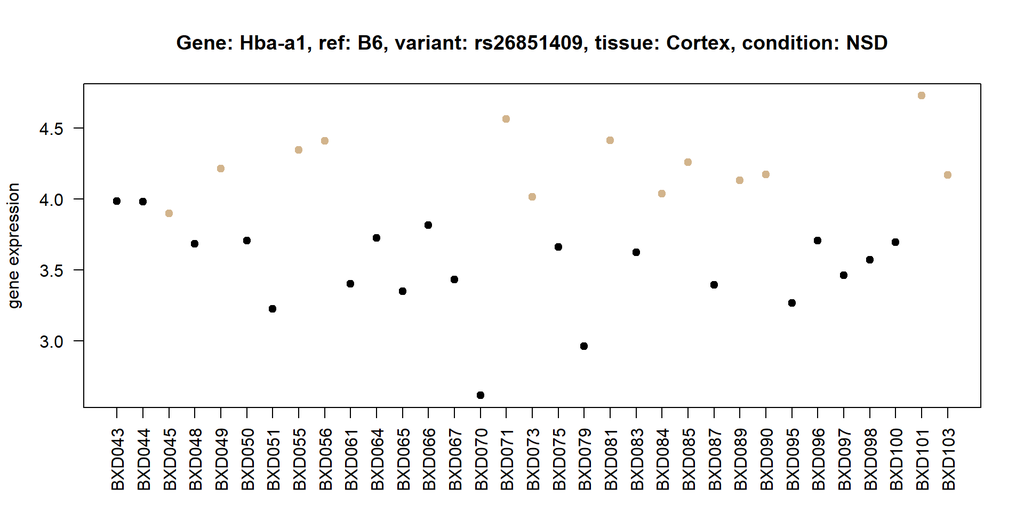

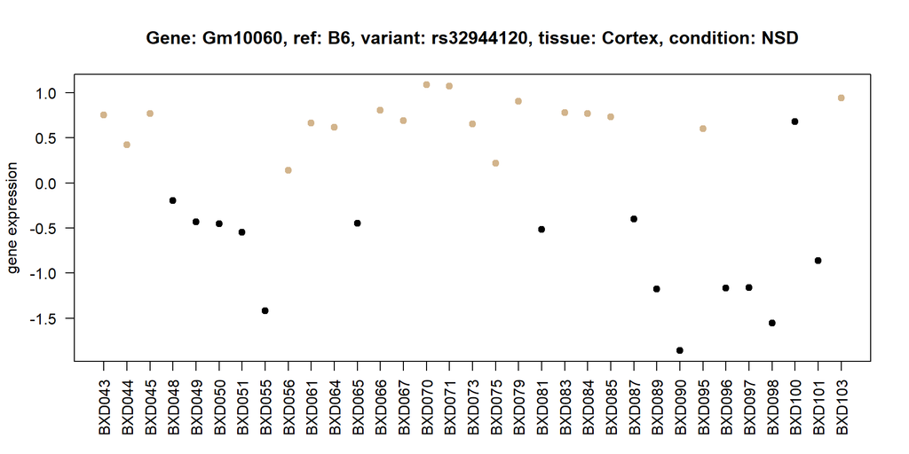

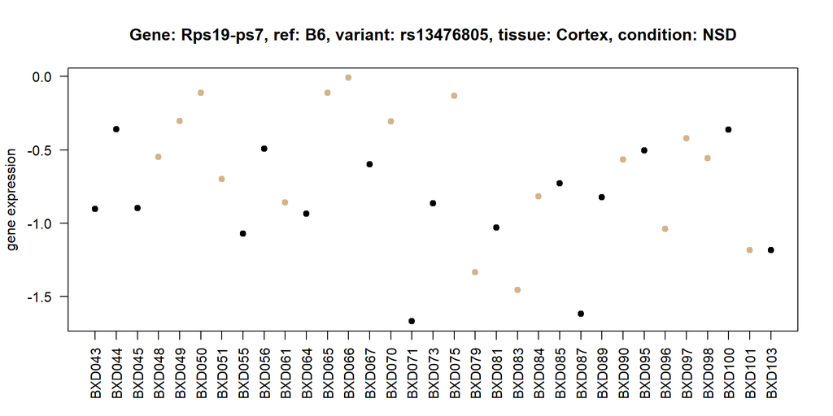

```
## $B6
##  [1]  1  2  3  4  5  6  7  8  9 10 11 12 13 14 15 16 17 18 19 20 21 22 23 24 25
## [26] 26 27 28 29 30 31 32 33
##
## $<NA>
##  [1]  1  2  3  4  5  6  7  8  9 10 11 12 13 14 15 16 17 18 19 20 21 22 23 24 25
## [26] 26 27 28 29 30 31 32 33
##
## $<NA>
##  [1]  1  2  3  4  5  6  7  8  9 10 11 12 13 14 15 16 17 18 19 20 21 22 23 24 25
## [26] 26 27 28 29 30 31 32 33
```

```r
# plot variant-gene expression pair
plotGeneExpressionVariant(ref="B6", gene=rownames(top3genesCNSD), variant=top3genesCNSD$variantB6, tissue="Cortex", condition="NSD")
```

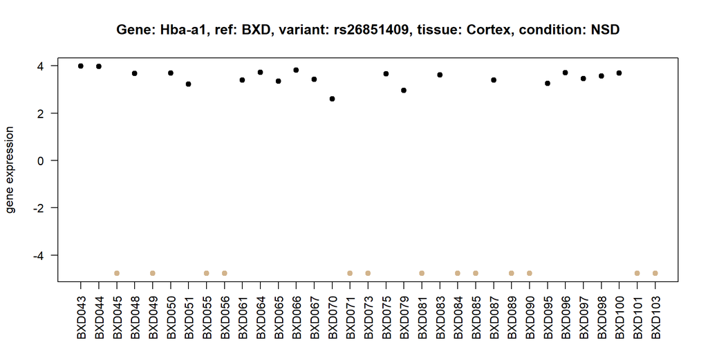

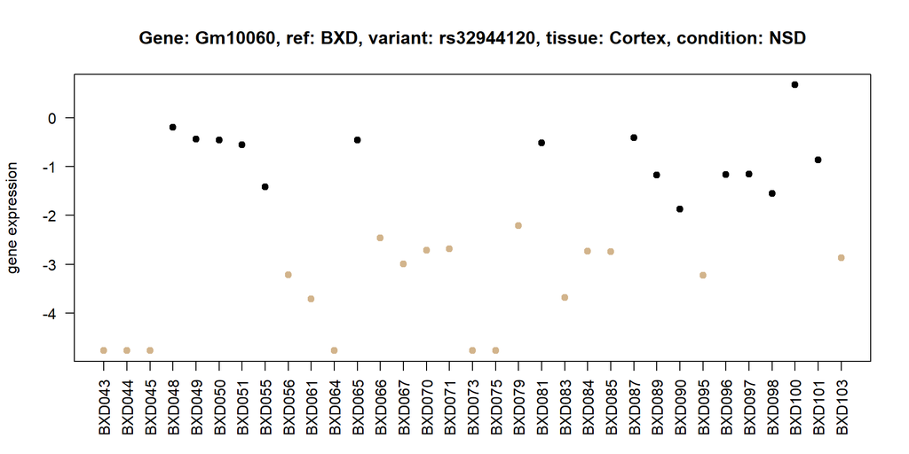

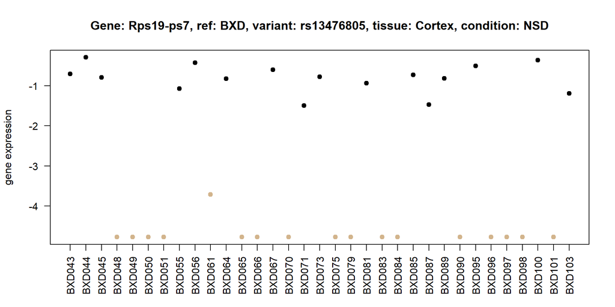

```
## $BXD
##  [1]  1  2  3  4  5  6  7  8  9 10 11 12 13 14 15 16 17 18 19 20 21 22 23 24 25
## [26] 26 27 28 29 30 31 32 33
##
## $<NA>
##  [1]  1  2  3  4  5  6  7  8  9 10 11 12 13 14 15 16 17 18 19 20 21 22 23 24 25
## [26] 26 27 28 29 30 31 32 33
##
## $<NA>
##  [1]  1  2  3  4  5  6  7  8  9 10 11 12 13 14 15 16 17 18 19 20 21 22 23 24 25
## [26] 26 27 28 29 30 31 32 33
```

```r
plotGeneExpressionVariant(ref="BXD", gene=rownames(top3genesCNSD), variant=top3genesCNSD$variantBXD, tissue="Cortex", condition="NSD")
```

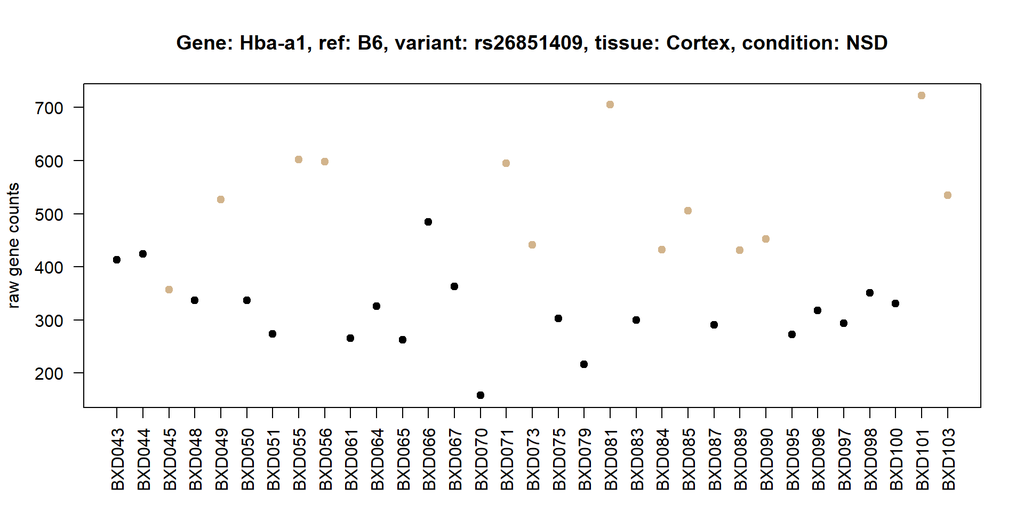

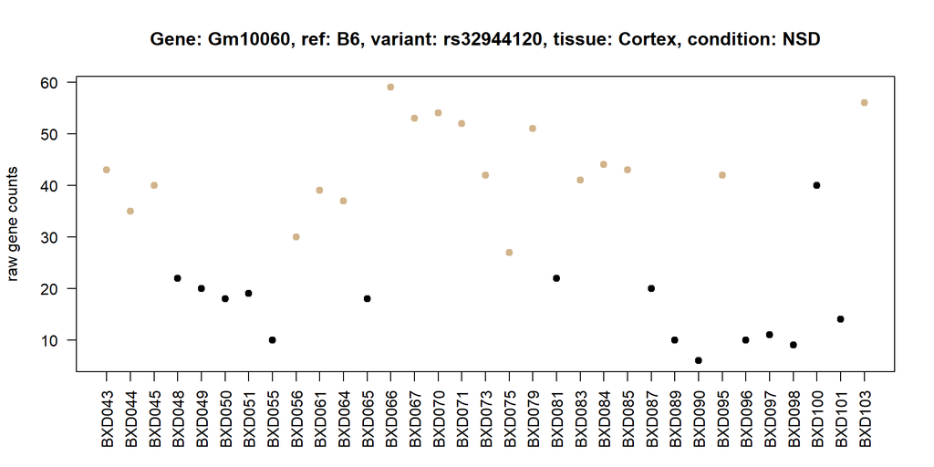

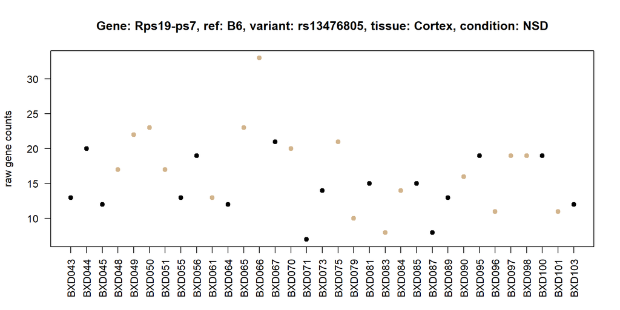

```
## $B6
##  [1]  1  2  3  4  5  6  7  8  9 10 11 12 13 14 15 16 17 18 19 20 21 22 23 24 25
## [26] 26 27 28 29 30 31 32 33
##
## $<NA>
##  [1]  1  2  3  4  5  6  7  8  9 10 11 12 13 14 15 16 17 18 19 20 21 22 23 24 25
## [26] 26 27 28 29 30 31 32 33
##
## $<NA>
##  [1]  1  2  3  4  5  6  7  8  9 10 11 12 13 14 15 16 17 18 19 20 21 22 23 24 25
## [26] 26 27 28 29 30 31 32 33
```

```r
# plot variant-gene count pair
plotGeneCountsVariant(ref="B6", gene=rownames(top3genesCNSD), variant=top3genesCNSD$variantB6, tissue="Cortex", condition="NSD")
```

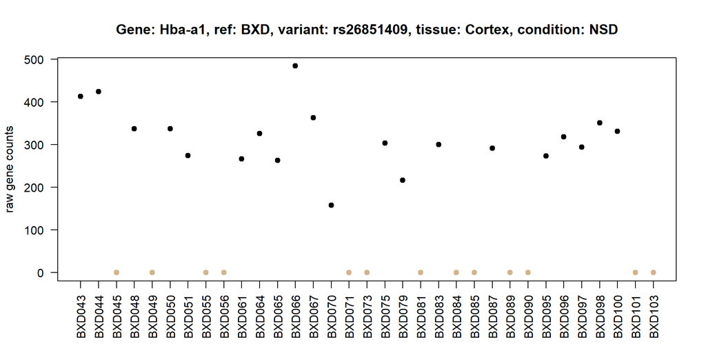

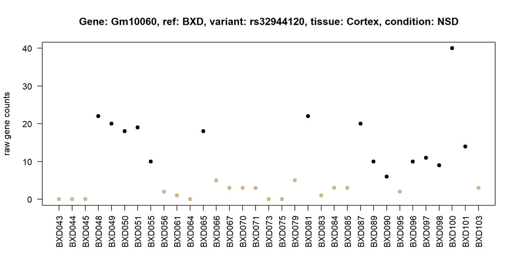

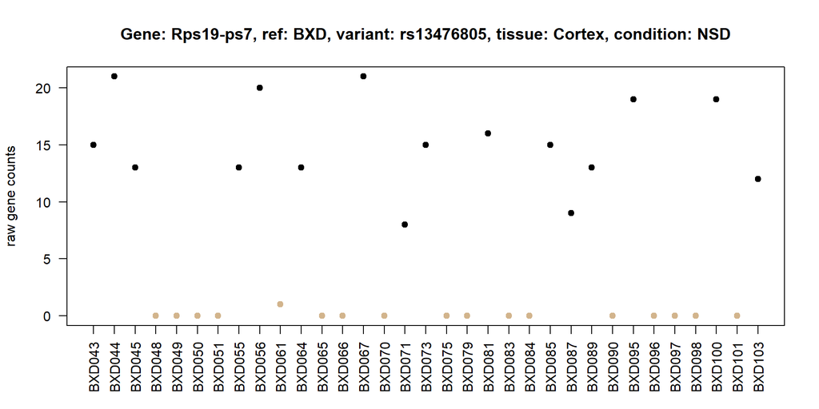

```
## $BXD
##  [1]  1  2  3  4  5  6  7  8  9 10 11 12 13 14 15 16 17 18 19 20 21 22 23 24 25
## [26] 26 27 28 29 30 31 32 33
##
## $<NA>
##  [1]  1  2  3  4  5  6  7  8  9 10 11 12 13 14 15 16 17 18 19 20 21 22 23 24 25
## [26] 26 27 28 29 30 31 32 33
##
## $<NA>
##  [1]  1  2  3  4  5  6  7  8  9 10 11 12 13 14 15 16 17 18 19 20 21 22 23 24 25
## [26] 26 27 28 29 30 31 32 33
```

```r
plotGeneCountsVariant(ref="BXD", gene=rownames(top3genesCNSD), variant=top3genesCNSD$variantBXD, tissue="Cortex", condition="NSD")
```

## Cortex SD

```r
# find and display information on
top3genes(tissue="Cortex", condition="SD")
top3genesCSD
```

|  | variantB6 | slopeB6 | qvalueB6 | variantBXD | slopeBXD | qvalueBXD |
| --- | --- | --- | --- | --- | --- | --- |
| Hba-a1 | rs26851409 | 0.3684160 | 1.067581e-04 | rs26851409 | -4.13655 | 7.985384e-31 |
| Gm10060 | rs32944120 | 0.6599530 | 1.938594e-08 | rs32944120 | -1.33190 | 5.689980e-11 |
| Gm4366 | rs32413905 | -0.0663238 | 3.794994e-01 | rs31002336 | -2.01737 | 5.423457e-17 |

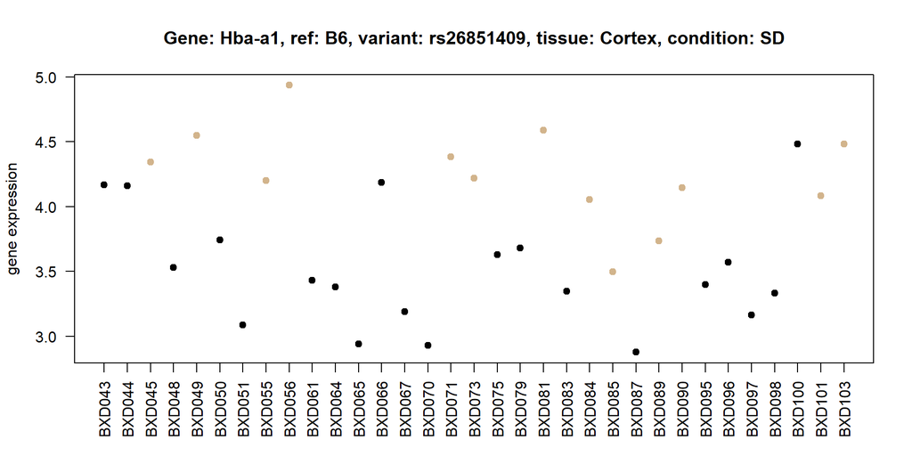

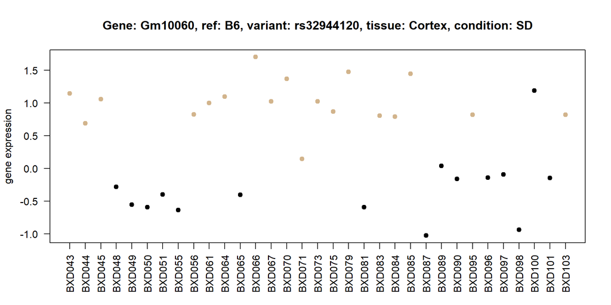

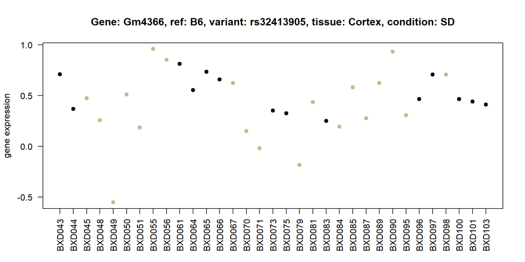

```
## $B6
##  [1]  1  2  3  4  5  6  7  8  9 10 11 12 13 14 15 16 17 18 19 20 21 22 23 24 25
## [26] 26 27 28 29 30 31 32 33
##
## $<NA>
##  [1]  1  2  3  4  5  6  7  8  9 10 11 12 13 14 15 16 17 18 19 20 21 22 23 24 25
## [26] 26 27 28 29 30 31 32 33
##
## $<NA>
##  [1]  1  2  3  4  5  6  7  8  9 10 11 12 13 14 15 16 17 18 19 20 21 22 23 24 25
## [26] 26 27 28 29 30 31 32 33
```

```r
# plot variant-gene expression pair
plotGeneExpressionVariant(ref="B6", gene=rownames(top3genesCSD), variant=top3genesCSD$variantB6, tissue="Cortex", condition="SD")
```

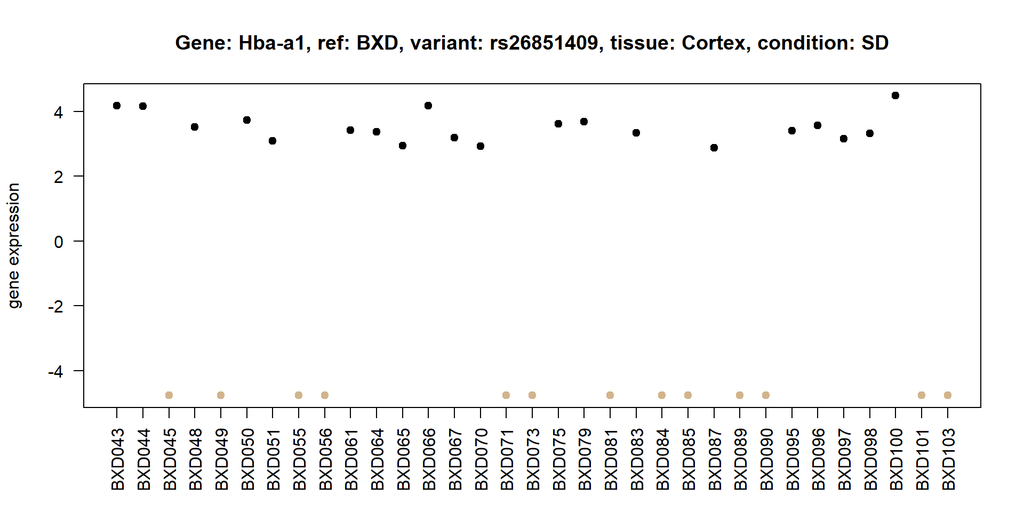

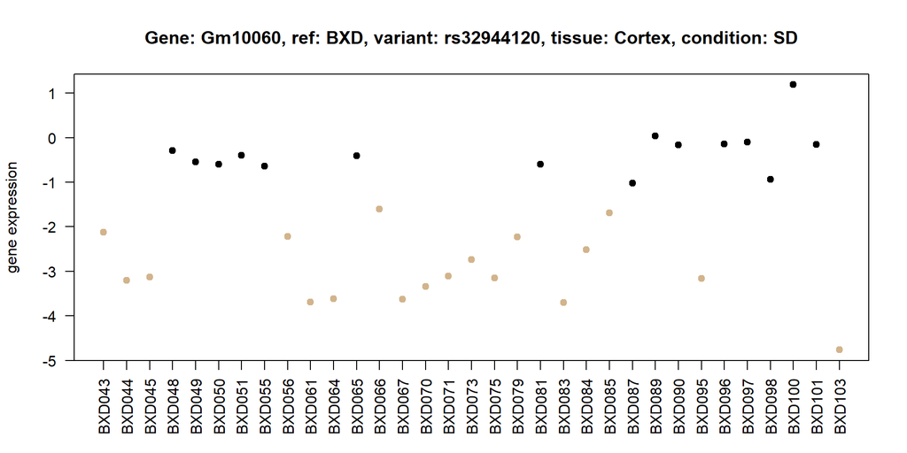

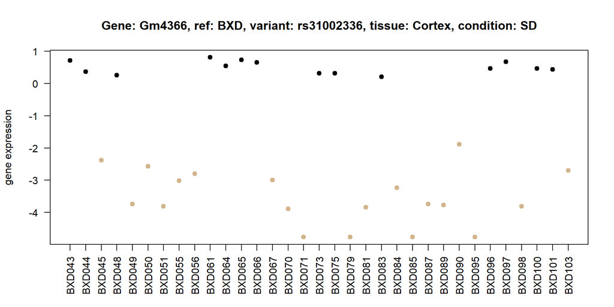

```
## $BXD
##  [1]  1  2  3  4  5  6  7  8  9 10 11 12 13 14 15 16 17 18 19 20 21 22 23 24 25
## [26] 26 27 28 29 30 31 32 33
##
## $<NA>
##  [1]  1  2  3  4  5  6  7  8  9 10 11 12 13 14 15 16 17 18 19 20 21 22 23 24 25
## [26] 26 27 28 29 30 31 32 33
##
## $<NA>
##  [1]  1  2  3  4  5  6  7  8  9 10 11 12 13 14 15 16 17 18 19 20 21 22 23 24 25
## [26] 26 27 28 29 30 31 32 33
```

```r
plotGeneExpressionVariant(ref="BXD", gene=rownames(top3genesCSD), variant=top3genesCSD$variantBXD, tissue="Cortex", condition="SD")
```

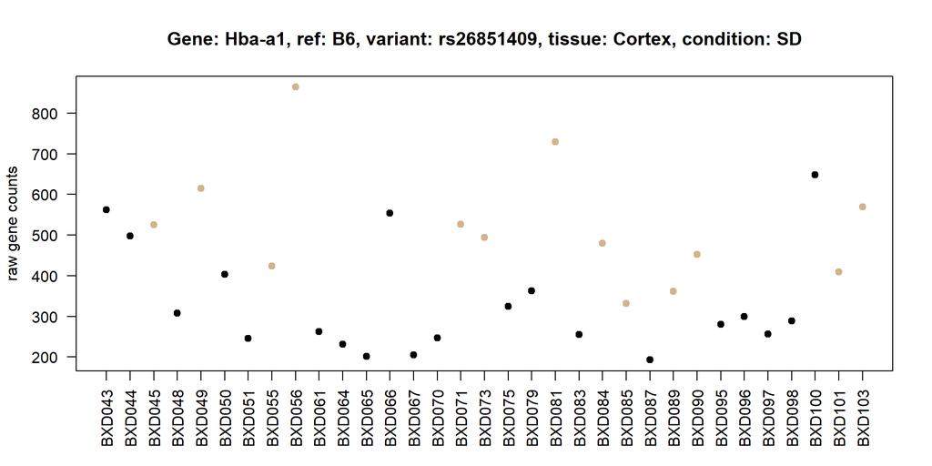

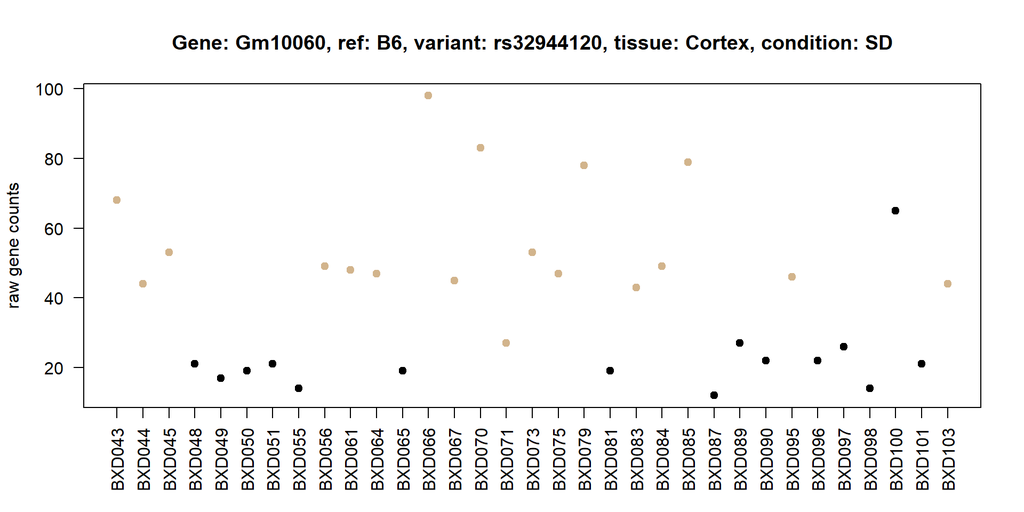

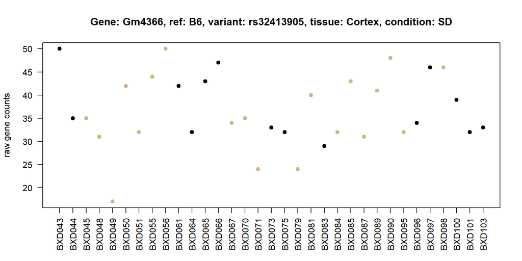

```
## $B6
##  [1]  1  2  3  4  5  6  7  8  9 10 11 12 13 14 15 16 17 18 19 20 21 22 23 24 25
## [26] 26 27 28 29 30 31 32 33
##
## $<NA>
##  [1]  1  2  3  4  5  6  7  8  9 10 11 12 13 14 15 16 17 18 19 20 21 22 23 24 25
## [26] 26 27 28 29 30 31 32 33
##
## $<NA>
##  [1]  1  2  3  4  5  6  7  8  9 10 11 12 13 14 15 16 17 18 19 20 21 22 23 24 25
## [26] 26 27 28 29 30 31 32 33
```

```r
# plot variant-gene count pair
plotGeneCountsVariant(ref="B6", gene=rownames(top3genesCSD), variant=top3genesCSD$variantB6, tissue="Cortex", condition="SD")
```

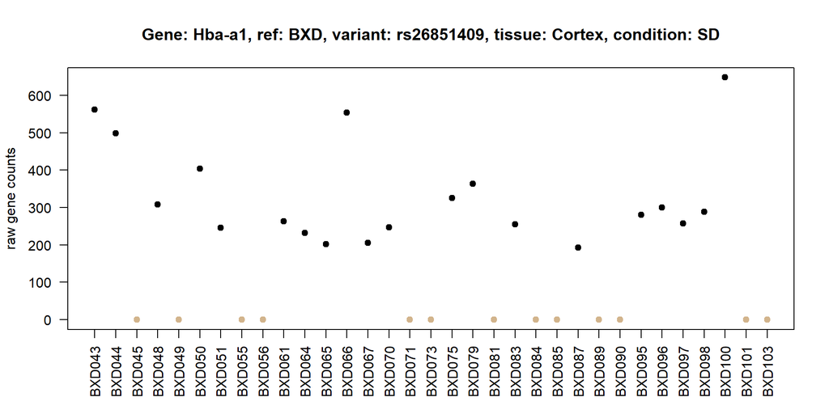

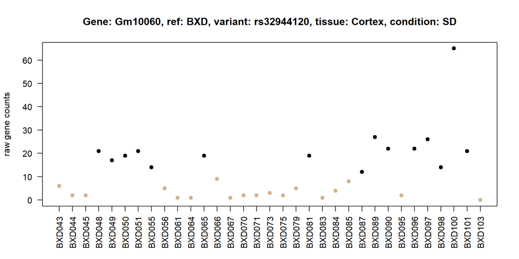

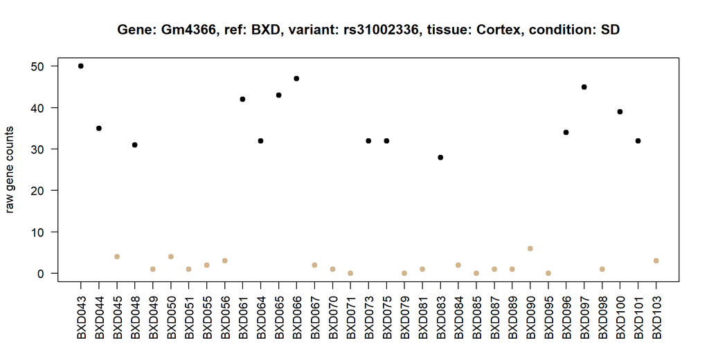

```
## $BXD
##  [1]  1  2  3  4  5  6  7  8  9 10 11 12 13 14 15 16 17 18 19 20 21 22 23 24 25
## [26] 26 27 28 29 30 31 32 33
##
## $<NA>
##  [1]  1  2  3  4  5  6  7  8  9 10 11 12 13 14 15 16 17 18 19 20 21 22 23 24 25
## [26] 26 27 28 29 30 31 32 33
##
## $<NA>
##  [1]  1  2  3  4  5  6  7  8  9 10 11 12 13 14 15 16 17 18 19 20 21 22 23 24 25
## [26] 26 27 28 29 30 31 32 33
```

```r
plotGeneCountsVariant(ref="BXD", gene=rownames(top3genesCSD), variant=top3genesCSD$variantBXD, tissue="Cortex", condition="SD")
```

About 2% of the genes are highly affected. Knowing we affected less than 1% of bp in the genome.

legend: black=B6 allele, tan=D2 allele

Checking for raw gene counts. There are comparable since we used the same reads on B6 or BXD references.

## Liver NSD

```r
# find and display information on
top3genes(tissue="Liver", condition="NSD")
top3genesLNSD
```

|  | variantB6 | slopeB6 | qvalueB6 | variantBXD | slopeBXD | qvalueBXD |
| --- | --- | --- | --- | --- | --- | --- |
| Hba-a1 | rs26851409 | 0.2891040 | 1.949576e-02 | rs26851409 | -4.51965 | 1.719196e-24 |
| Serpina1e | rs13481620 | -2.4497900 | 1.242407e-24 | rs13481620 | -5.73667 | 6.711274e-27 |
| Gm49011 | rs13482263 | -0.0971907 | 3.899669e-01 | rs13482263 | -3.14519 | 5.092497e-20 |

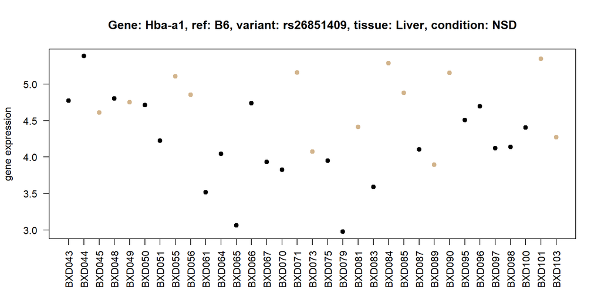

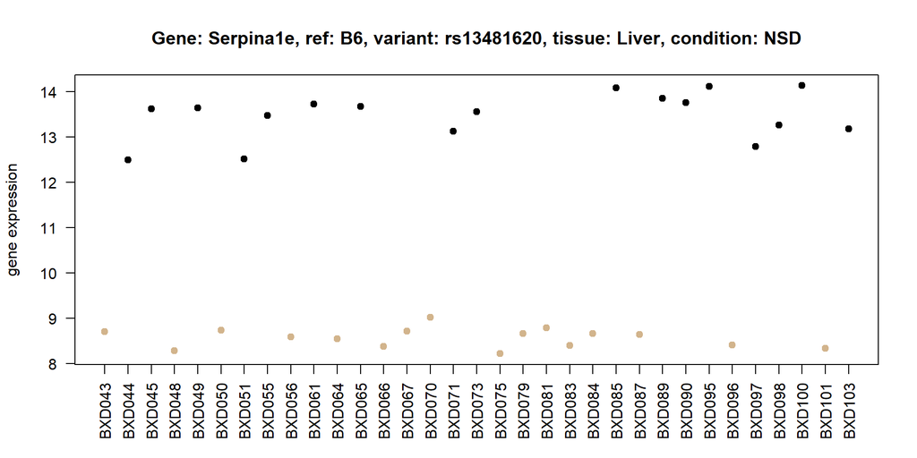

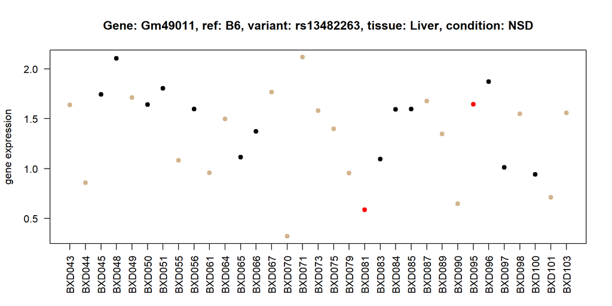

```
## $B6
##  [1]  1  2  3  4  5  6  7  8  9 10 11 12 13 14 15 16 17 18 19 20 21 22 23 24 25
## [26] 26 27 28 29 30 31 32 33
##
## $<NA>
##  [1]  1  2  3  4  5  6  7  8  9 10 11 12 13 14 15 16 17 18 19 20 21 22 23 24 25
## [26] 26 27 28 29 30 31 32 33
##
## $<NA>
##  [1]  1  2  3  4  5  6  7  8  9 10 11 12 13 14 15 16 17 18 19 20 21 22 23 24 25
## [26] 26 27 28 29 30 31 32 33
```

```r
# plot variant-gene expression pair
plotGeneExpressionVariant(ref="B6", gene=rownames(top3genesLNSD), variant=top3genesLNSD$variantB6, tissue="Liver", condition="NSD")
```

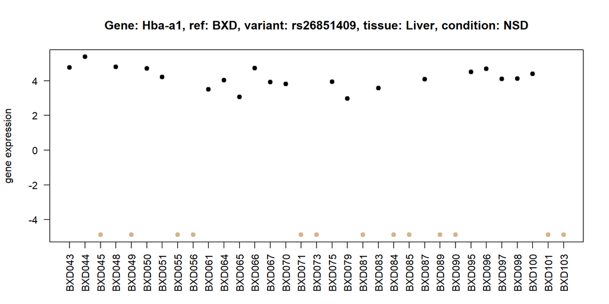

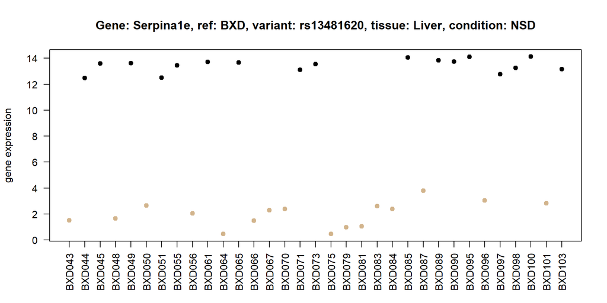

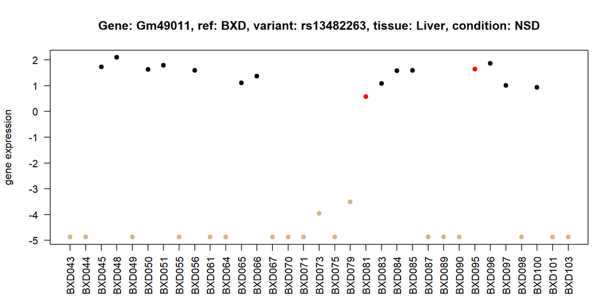

```
## $BXD
##  [1]  1  2  3  4  5  6  7  8  9 10 11 12 13 14 15 16 17 18 19 20 21 22 23 24 25
## [26] 26 27 28 29 30 31 32 33
##
## $<NA>
##  [1]  1  2  3  4  5  6  7  8  9 10 11 12 13 14 15 16 17 18 19 20 21 22 23 24 25
## [26] 26 27 28 29 30 31 32 33
##
## $<NA>
##  [1]  1  2  3  4  5  6  7  8  9 10 11 12 13 14 15 16 17 18 19 20 21 22 23 24 25
## [26] 26 27 28 29 30 31 32 33
```

```r
plotGeneExpressionVariant(ref="BXD", gene=rownames(top3genesLNSD), variant=top3genesLNSD$variantBXD, tissue="Liver", condition="NSD")
```

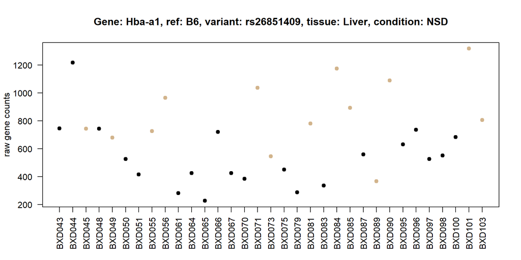

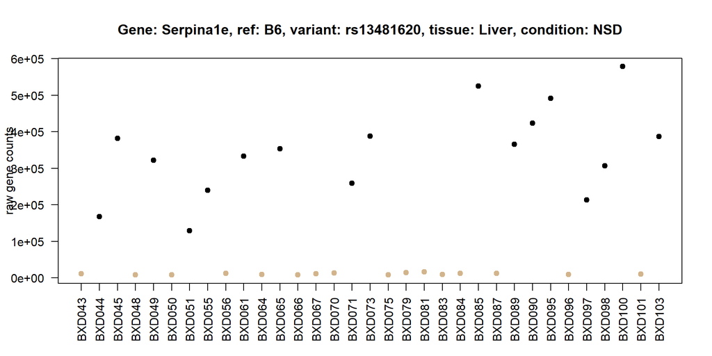

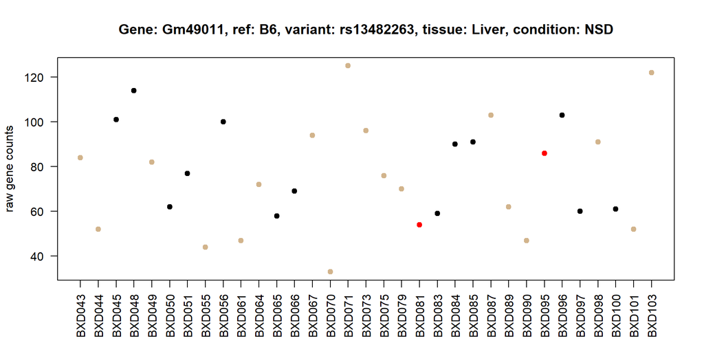

```
## $B6
##  [1]  1  2  3  4  5  6  7  8  9 10 11 12 13 14 15 16 17 18 19 20 21 22 23 24 25
## [26] 26 27 28 29 30 31 32 33
##
## $<NA>
##  [1]  1  2  3  4  5  6  7  8  9 10 11 12 13 14 15 16 17 18 19 20 21 22 23 24 25
## [26] 26 27 28 29 30 31 32 33
##
## $<NA>
##  [1]  1  2  3  4  5  6  7  8  9 10 11 12 13 14 15 16 17 18 19 20 21 22 23 24 25
## [26] 26 27 28 29 30 31 32 33
```

```r
# plot variant-gene count pair
plotGeneCountsVariant(ref="B6", gene=rownames(top3genesLNSD), variant=top3genesLNSD$variantB6, tissue="Liver", condition="NSD")
```

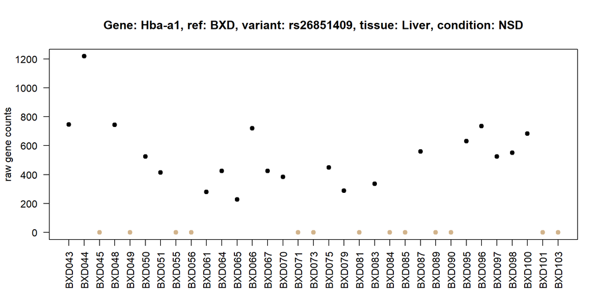

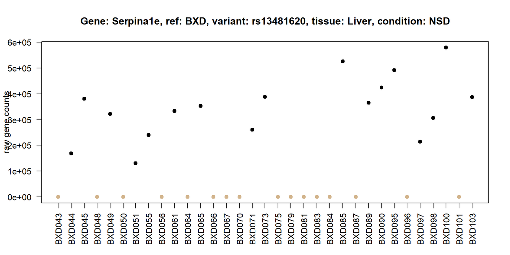

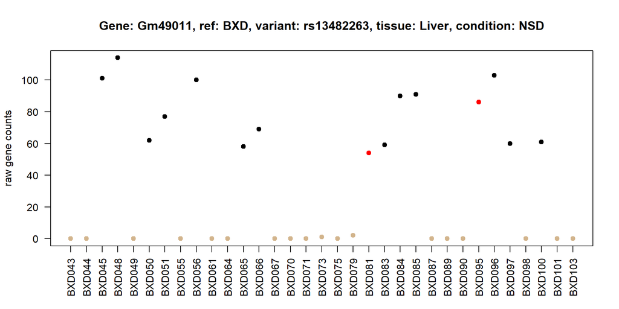

```
## $BXD
##  [1]  1  2  3  4  5  6  7  8  9 10 11 12 13 14 15 16 17 18 19 20 21 22 23 24 25
## [26] 26 27 28 29 30 31 32 33
##
## $<NA>
##  [1]  1  2  3  4  5  6  7  8  9 10 11 12 13 14 15 16 17 18 19 20 21 22 23 24 25
## [26] 26 27 28 29 30 31 32 33
##
## $<NA>
##  [1]  1  2  3  4  5  6  7  8  9 10 11 12 13 14 15 16 17 18 19 20 21 22 23 24 25
## [26] 26 27 28 29 30 31 32 33
```

```r
plotGeneCountsVariant(ref="BXD", gene=rownames(top3genesLNSD), variant=top3genesLNSD$variantBXD, tissue="Liver", condition="NSD")
```

## Liver SD

```r
# find and display information on
top3genes(tissue="Liver", condition="SD")
top3genesLSD
```

|  | variantB6 | slopeB6 | qvalueB6 | variantBXD | slopeBXD | qvalueBXD |
| --- | --- | --- | --- | --- | --- | --- |
| Hba-a1 | rs26851409 | 0.3709440 | 2.342184e-02 | rs26851409 | -4.35525 | 1.184742e-23 |
| Serpina1e | rs13481620 | -2.4031300 | 4.301004e-25 | rs13481620 | -5.68948 | 2.980259e-25 |
| Gm49011 | rs30565505 | -0.0477706 | 5.996748e-01 | rs13482263 | -2.89644 | 1.207263e-18 |

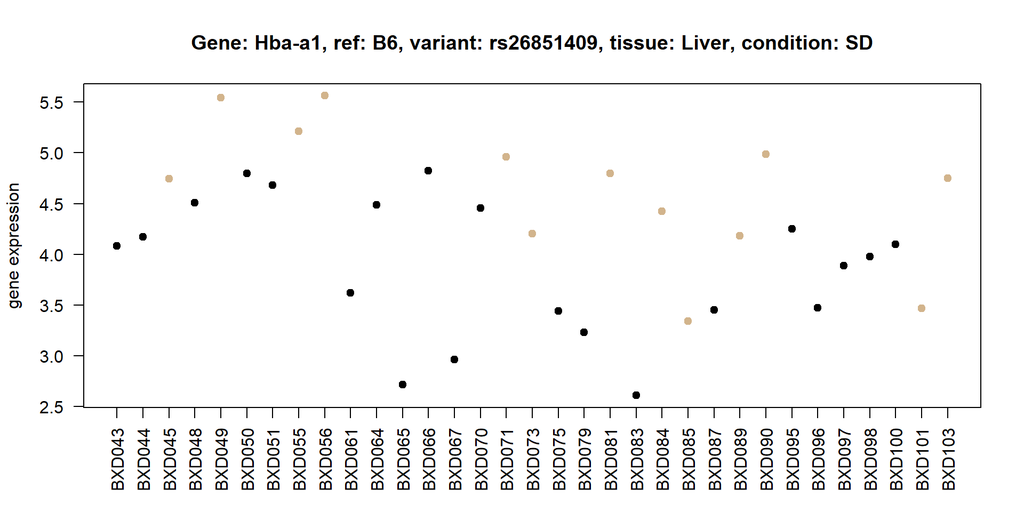

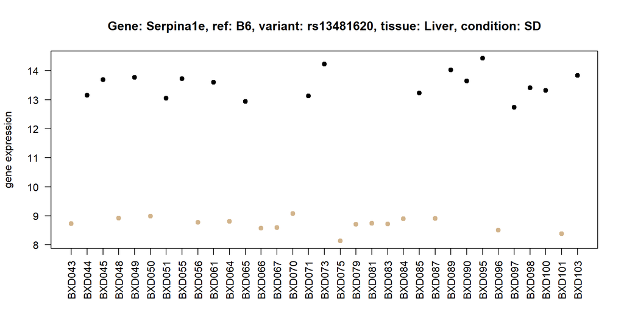

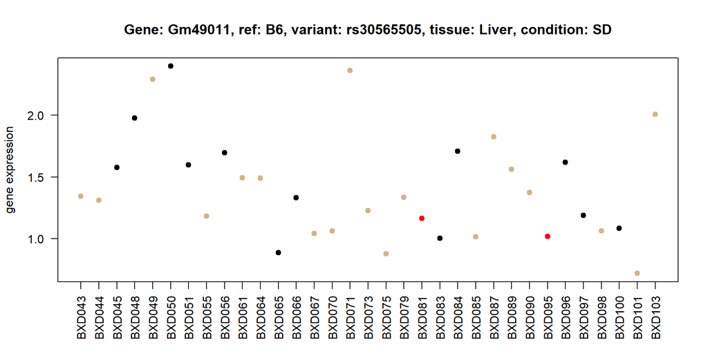

```
## $B6
##  [1]  1  2  3  4  5  6  7  8  9 10 11 12 13 14 15 16 17 18 19 20 21 22 23 24 25
## [26] 26 27 28 29 30 31 32 33
##
## $<NA>
##  [1]  1  2  3  4  5  6  7  8  9 10 11 12 13 14 15 16 17 18 19 20 21 22 23 24 25
## [26] 26 27 28 29 30 31 32 33
##
## $<NA>
##  [1]  1  2  3  4  5  6  7  8  9 10 11 12 13 14 15 16 17 18 19 20 21 22 23 24 25
## [26] 26 27 28 29 30 31 32 33
```

```r
# plot variant-gene expression pair
plotGeneExpressionVariant(ref="B6", gene=rownames(top3genesLSD), variant=top3genesLSD$variantB6, tissue="Liver", condition="SD")
```

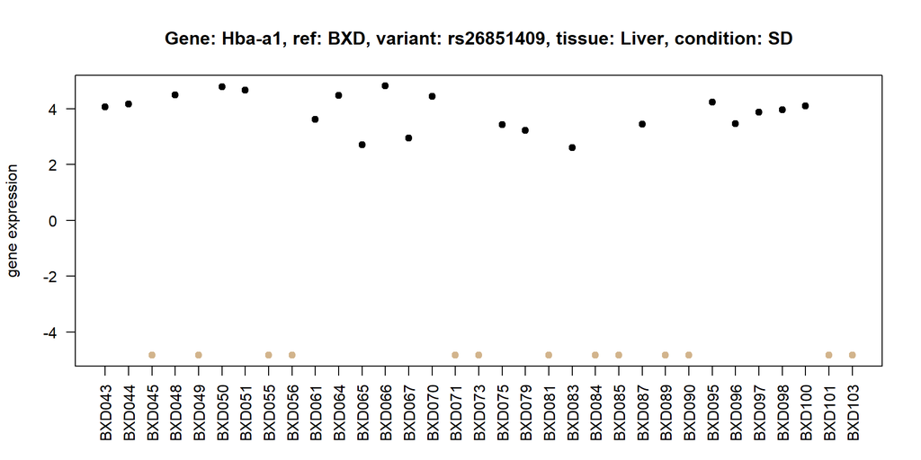

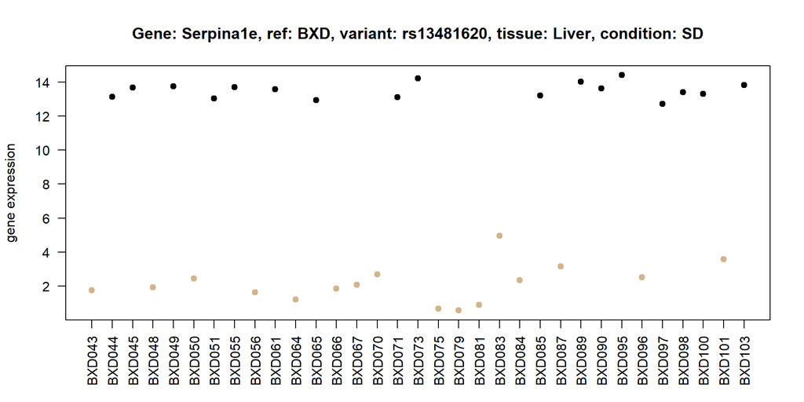

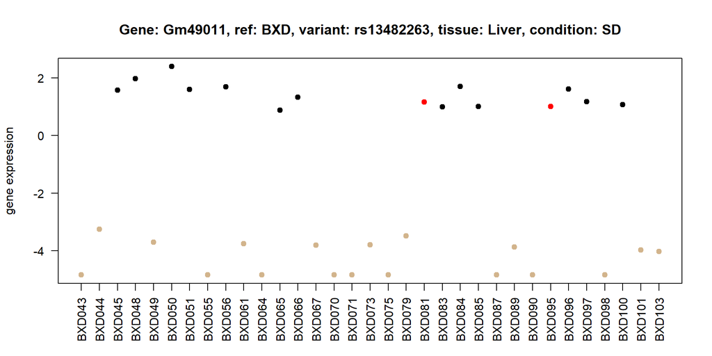

```
## $BXD
##  [1]  1  2  3  4  5  6  7  8  9 10 11 12 13 14 15 16 17 18 19 20 21 22 23 24 25
## [26] 26 27 28 29 30 31 32 33
##
## $<NA>
##  [1]  1  2  3  4  5  6  7  8  9 10 11 12 13 14 15 16 17 18 19 20 21 22 23 24 25
## [26] 26 27 28 29 30 31 32 33
##
## $<NA>
##  [1]  1  2  3  4  5  6  7  8  9 10 11 12 13 14 15 16 17 18 19 20 21 22 23 24 25
## [26] 26 27 28 29 30 31 32 33
```

```r
plotGeneExpressionVariant(ref="BXD", gene=rownames(top3genesLSD), variant=top3genesLSD$variantBXD, tissue="Liver", condition="SD")
```

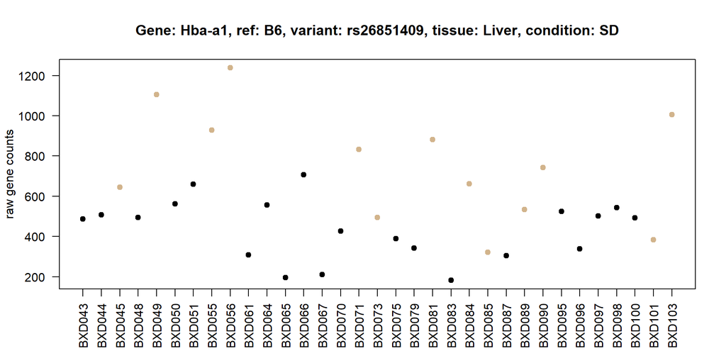

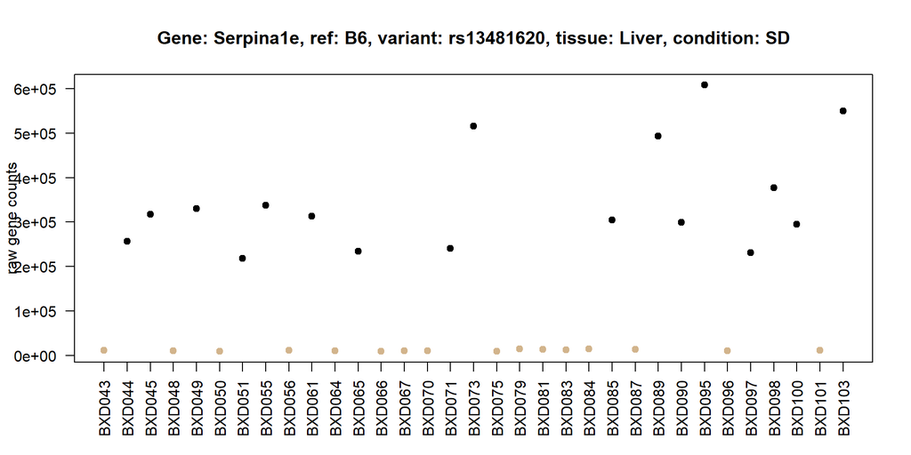

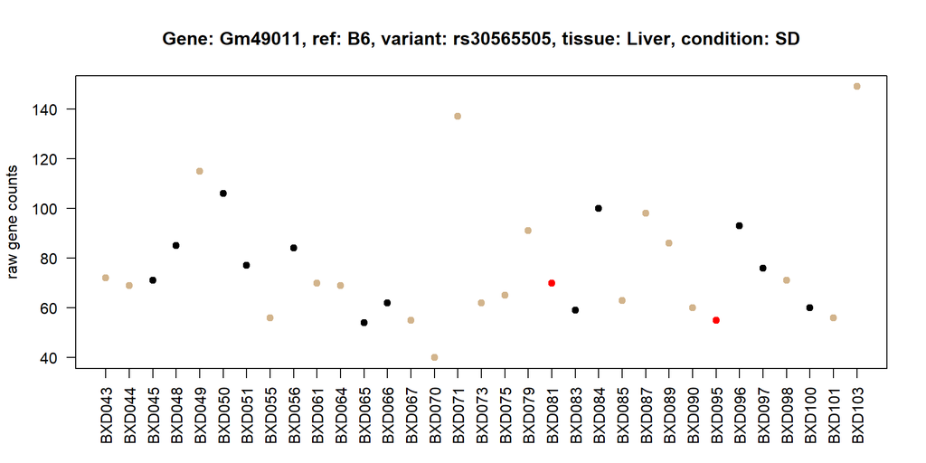

```
## $B6
##  [1]  1  2  3  4  5  6  7  8  9 10 11 12 13 14 15 16 17 18 19 20 21 22 23 24 25
## [26] 26 27 28 29 30 31 32 33
##
## $<NA>
##  [1]  1  2  3  4  5  6  7  8  9 10 11 12 13 14 15 16 17 18 19 20 21 22 23 24 25
## [26] 26 27 28 29 30 31 32 33
##
## $<NA>
##  [1]  1  2  3  4  5  6  7  8  9 10 11 12 13 14 15 16 17 18 19 20 21 22 23 24 25
## [26] 26 27 28 29 30 31 32 33
```

```r
# plot variant-gene count pair
plotGeneCountsVariant(ref="B6", gene=rownames(top3genesLSD), variant=top3genesLSD$variantB6, tissue="Liver", condition="SD")
```

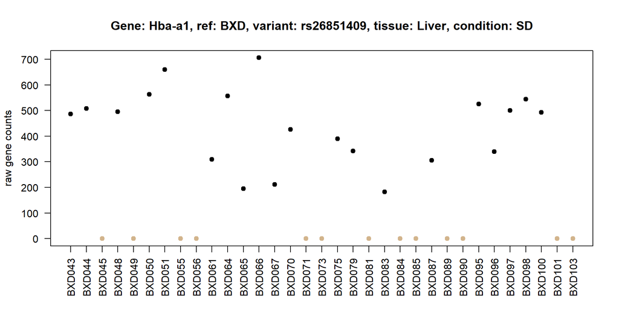

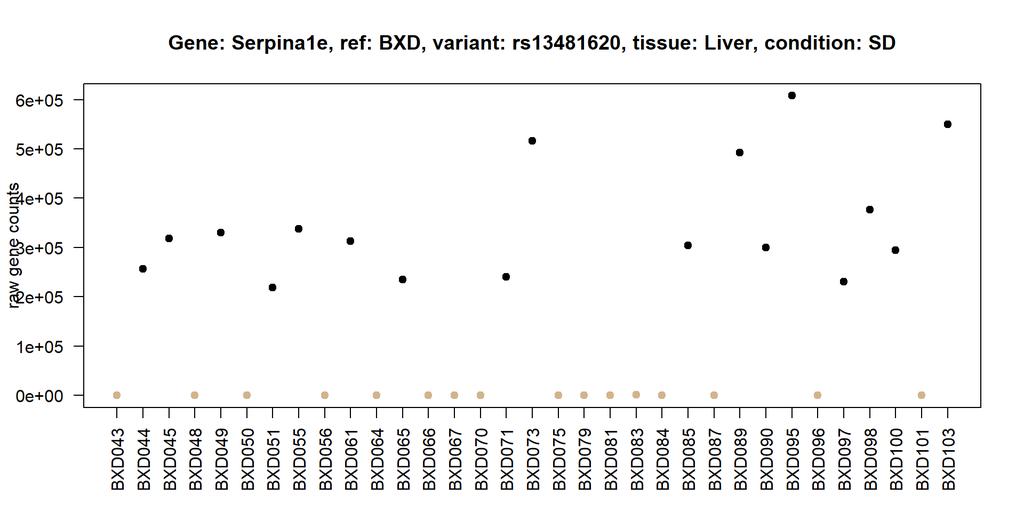

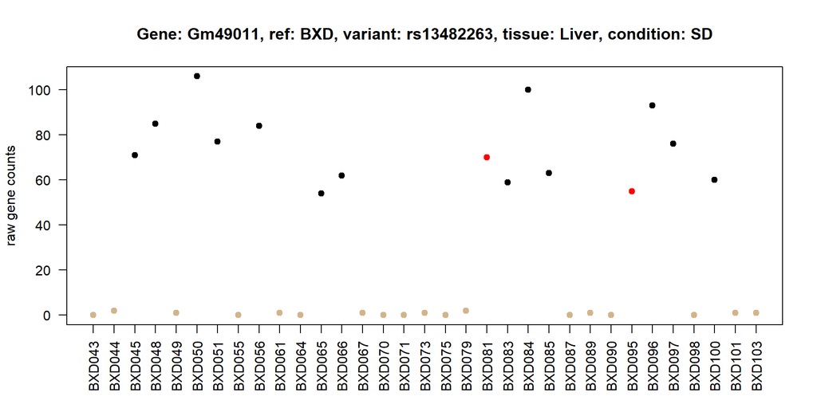

```
## $BXD
##  [1]  1  2  3  4  5  6  7  8  9 10 11 12 13 14 15 16 17 18 19 20 21 22 23 24 25
## [26] 26 27 28 29 30 31 32 33
##
## $<NA>
##  [1]  1  2  3  4  5  6  7  8  9 10 11 12 13 14 15 16 17 18 19 20 21 22 23 24 25
## [26] 26 27 28 29 30 31 32 33
##
## $<NA>
##  [1]  1  2  3  4  5  6  7  8  9 10 11 12 13 14 15 16 17 18 19 20 21 22 23 24 25
## [26] 26 27 28 29 30 31 32 33
```

```r
plotGeneCountsVariant(ref="BXD", gene=rownames(top3genesLSD), variant=top3genesLSD$variantBXD, tissue="Liver", condition="SD")
```